# Coding standards and creating packages in R

Tom Wilson

October 2024

## Contents

- What are coding standards and why use them?
- Style guides for R.
- Code formatting and linting tools.
- Creating documentation.
- Creating an R package.

## What are coding standards?

Guidelines and best practices for writing clean, consistent, maintainable code. They include:

- **Naming conventions** for variables, functions, classes, files.
- **Formatting** rules to make your code easier to read.
- **Documenting and commenting** standards.
- **Best practices** for writing efficient code, reducing errors.

Coding standards are often described in **Style Guides**.

## Why use coding standards?

*“Code is read much more often than it is written”*  
Guido van Rossum

- To make your code more readable.
- Therefore more easily understood.
- Therefore more likely to find reviewers, collaborators.
- Make your code look more professional.
- It saves you inventing your own conventions.
- **Most importantly, be consistent!**

## Style Guides

- [Tidyverse Style Guide](https://style.tidyverse.org/)
- [Google’s R Style Guide](https://google.github.io/styleguide/Rguide.html)

## Tidyverse Style Guide

Some of its syntax suggestions:

- Variables and function names should only contain lowercase letters, numbers and _
- Always use `<-` not `=` for variable assignment
- One space after commas and either side of assignment `<-` `=` and comparators like `>` `<` `==` etc
- Keep to lines to max 80 characters
- Use `"` not `'` for quoting text
- When using `function`, `if`, `for`, `while`:
  - Opening `{` should be last character on a line
  - Then two space indent
  - Closing `}` should be first character on a line

## Tidyverse Style Guide

A simple example:

```r
# Ignoring TidyVerse Style Guide ----
myVector=c(10,20,30)

myCalc=function(x,Multiplier){x*Multiplier}

myCalc(myVector,Multiplier=10)


# Applying TidyVerse Style Guide ----
my_vector <- c(10, 20, 30)

my_calc <- function(x, multiplier) {
  x * multiplier
}

my_calc(my_vector, multiplier = 10)
```

## Tools to help

- **Code formatters**
  - reformat code to match a particular style.
  - mostly spacing, indentation, not renaming variables!
- **Code linters**
  - flag potential bugs, poor practice, style violations.
  - linters do not change the code, but inform of problems.

  | Tool Type | R Packages |
  | --- | --- |
  | Formatter | [styler](https://styler.r-lib.org/index.html), [formatR](https://yihui.org/formatr/) |
  | Linter | [lintr](https://lintr.r-lib.org/) |

## styler and lintr

Use these tools from the R Studio Addins menu once the packages are installed.

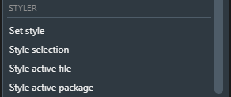

In R Studio any issues flagged by `lintr` are shown in a Markers tab:

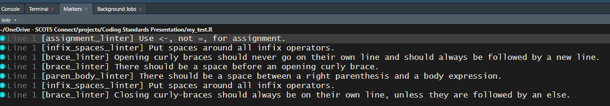

Unfortunately R Studio does not have on save option for running formatters.

## Continuous Integration (CI)

- Automated builds and tests are run when code changes are pushed to a central repository.
- GitHub Actions might be used to run a specific formatter or linter as part of a CI pipeline.

[figure not shown]

- GitHub Actions can be configured to run when opening a GitHub Pull Request.
- GitHub Actions can be configured so cannot merge a branch unless the checks pass.
- This is an advanced topic. Other CI tools are available Travis CI, Jenkins.

## Creating Documention in R

- For R functions add Roxygen comments to document them.
- Using R Studio insert a Roxygen template (R Studio > Code menu > Insert Roxygen Skeleton).

```r
#' My calculation
#'
#' @param x numeric vector or number to be multiplied.
#' @param multiplier the scaler value to multiply x by.
#'
#' @return scaled value
#' @export
#'
#' @examples
#' my_calc(c(1, 2, 3), 10)
my_calc <- function(x, multiplier) {
  x * multiplier
}
```

- When developing an R package `roxygen2::roxygenise()` is used to generate the documentation `.Rd` files from the roxygen comments.
- See documentation section of the [Tidyverse Style Guide](https://style.tidyverse.org/documentation.html) and also in the [R Packages online book](https://r-pkgs.org/man.html).

## What is an R Package?

- A package is what install from [CRAN](https://cran.r-project.org/) (or an internal server) with `install.packages()` and load with `library()`.
- Bundles R code within functions so they are usable by others after they install and load the package.
- A package can include documentation, sample data, test scripts.
- It is surprisingly easy to create an R package.

## Why create an R Package?

- Sharing: Make processes you have developed easily accessible to others by installing the package, not copying and pasting code or script files.
- Reusability: Packages will usually bundle functionality that may be used across many projects.
- Clarity: R packages all follow a similar format in where R code is stored, how documentation is created, how test scripts are written. Instead of each person inventing their own way.
- Knowledge: Developing an R package leads to a better understanding of how R works.

## Reference materials for creating an R package

- [R Packages](https://r-pkgs.org/) by Hadley Wickham and Jenny Bryan. Easy to follow introductory guide, based around [devtools](https://cran.r-project.org/web/packages/devtools/index.html) and related libraries.
- [Writing R Extensions](https://cran.r-project.org/doc/manuals/R-exts.html). Definitive guide on CRAN for reference.

## R packages to help to create a package

- [devtools](https://cran.r-project.org/web/packages/devtools/index.html) a bit like a ‘tidyverse’ for package development.
- [usethis](https://cran.r-project.org/web/packages/usethis/index.html) automating package setup and configuration tasks.
- [roxygen2](https://cran.r-project.org/web/packages/roxygen2/index.html) documentation and management of package metadata files.
- [testthat](https://cran.r-project.org/web/packages/testthat/index.html) formal unit testing of packages.

## Examples

- Many popular R packages have their code open on GitHub. For example dplyr

Some examples of packages developed and used in Scottish Government:

- sgplot
- RtoSQLServer
- opendatascot

## Summary

- Try to follow a style guide for your code and have a consistent approach.
- For R, see [Tidyverse Style Guide](https://style.tidyverse.org/).
- Code formatters automatically reformat parts (but not all) of your code to match a style guide. See [styler](https://styler.r-lib.org/index.html) package.
- Code linters run checks on style, best practices, errors. See [lintr](https://lintr.r-lib.org/) package.
- Creating an R package is the best way to make a process you have developed available to others.
- R packages are not difficult to create. Recommend reading [R Packages](https://r-pkgs.org/).